# TSA lab 4

```r
load(url("https://people.maths.bris.ac.uk/~magpn/TSA/TSA.RData")) #access data
```

1 Fitting an ARIMA model

This is a continuation of Example 2 in Lab One. The land-air temperature anomalies (from 1961- 1990 average), measured in degrees centigrade, for the years 1900-1997, are stored in the data set gtemp. We follow the flowchart to identify whether an ARIMA model is appropriate for this data set.

1. Plot the time series. Does it look stationary in mean? If not, difference the data using the R function diff() and put it into another vector called dgtemp. Plot the differenced data. Does it appear stationary? If so, then set the order of differencing d = 1, otherwise difference again and increase d accordingly. (Actually, d = 1 looks reasonable).

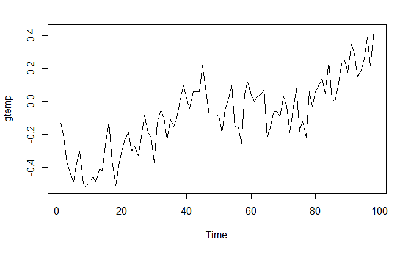

```r
ts.plot(gtemp) #plot gtemp data
```

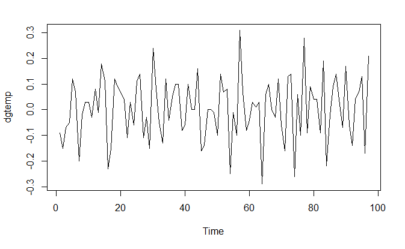

```r
#this doesn't look stationary
dgtemp <- diff(gtemp) #difference gtemp
ts.plot(dgtemp) # plot differenced data
```

2. Plot the correlogram of the differenced data using the acf() function. Are any of the correlation coefficients much larger than the tolerance limits?

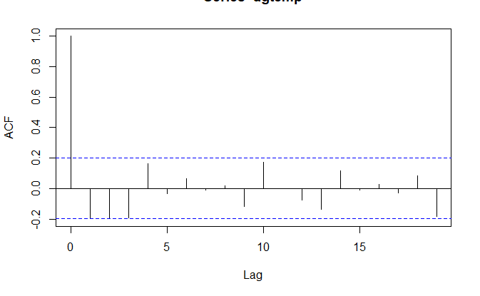

```r
acf(dgtemp) #plot autocorrellation of differenced gtemp
```

None of the lags are significantly large, other than k=0.

3. Plot the partial correlogram of the differenced data. Are any of the partial autocorrelation coefficients much larger than the tolerance limits?

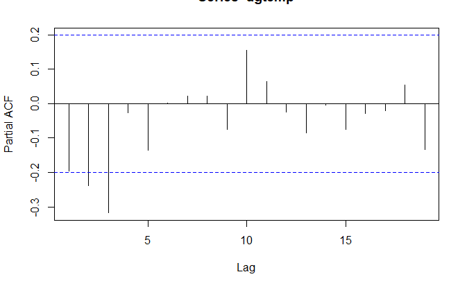

```r
pacf(dgtemp) #plot partial autocorrellation of differenced gtemp
```

Lags k=2 and k=3 are significantly larger than the tolerance interval.

4. Suggest a suitable model for the difference data and write down the fitted model. Hint: The fit can be obtained with the arima() function.

I have that d=1 since I have differenced the series once to obtain a stationary sequence. The PACF indicates I should use p=3 for the AR parameter, as the last significant time step with correllation not accounted for by the ACF is at step 3. The ACF implies I should use q=0, as there are no significant correlations with previous time steps. Hence, I use the model ARIMA(3,1,0) for the gtemp series.

```r
arima(gtemp, order = c(3,1,0))
```

```
Call:
arima(x = gtemp, order = c(3, 1, 0))

Coefficients:
          ar1      ar2      ar3
      -0.3351  -0.3245  -0.3388
s.e.   0.0978   0.0979   0.0988

sigma^2 estimated as 0.0117:  log likelihood = 77.85,  aic = -147.69
```

So I have the model dXt = -0.3351Xt-1 -0.3245Xt-2 -0.3388Xt-3 +Zt

//////////////////////////////////

2 Exponential smoothing

1. Implement the es() function now in R (type in the above definition of es() just as it appears. You can type RETURN wherever any space occurs to split the typing over more than one line).

```r
es <- function(x, alpha){sum(rev(x)*alpha*(1-alpha)^(0:(length(x)-1)))}
```

2. Now create a new data vector from the Lynx data by copying all the observations in the Lynx data set apart from the last one by using the command lynx2 <- lynx[1:113] The last value of the lynx data set is lynx[length(lynx)] which is l114 = 3396.

```r
lynx2 <- lynx[1:113] #define 1-step lynx vector
```

3. Now use exponential smoothing on lynx2 with varying values of ??. For example, es(lynx2,0.2), try some others. This can be done by the following R commands. forecasts=NULL alphas=seq(from=0.1, to=1, by=0.05) for(i in alphas) forecasts=c(forecasts, es(lynx2,i)) plot(alphas, forecasts) The plot suggests that the best value of ?? = 1 as this is closest to the true value l114 = 3396. However, the above procedure is not very good for the lynx data set because of the seasonality in the data.

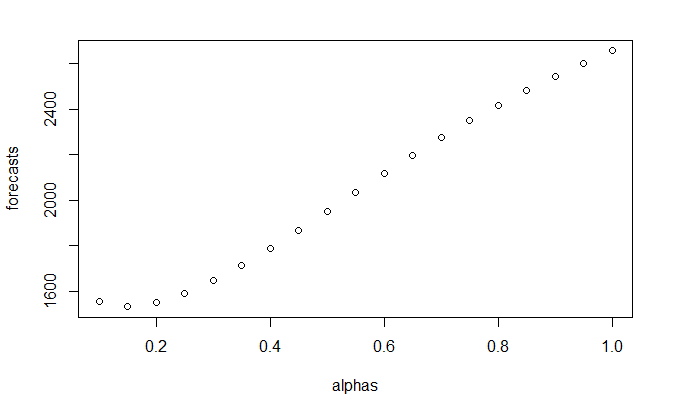

```r
forecasts=NULL
alphas=seq(from=0.1, to=1, by=0.05)
for(i in alphas) forecasts=c(forecasts, es(lynx2,i))
plot(alphas, forecasts)
```

4. To try and correct for the obvious cyclic behaviour (every 10 years?) in the series, create a new series from the lynx set by differencing the data with a lag of 10. In other words, if the lynx series is represented by lt form dt = lt ??? lt???10 for t = 11, . . . , 114. In R you can do this by lynx10 <- diff(lynx, lag=10) Plot the new differenced time series (use ts.plot). This looks less seasonal.

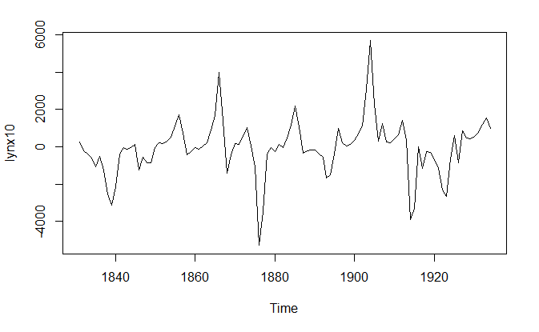

```r
lynx10 <- diff(lynx, lag=10) #difference lynx at lag k=10
ts.plot(lynx10)
```

5. Suppose we are interested in finding a forecast for LN+1. Rewrite the formula in part (d) to get Lt = Dt + Lt???10. We have capitalized letters because we are dealing with the idea of what the model is behind the process. Then stepping one time step into the future gives Lt+1 = Dt+1 + Lt???9. When we are trying to forecast LN+1 we just set t = N into the equation, i.e., LN+1 = DN+1 + LN???9.
6. Use exponential smoothing on the Dt to get a “sensible” estimate for DN+1. Then we may use this estimate and the actual value lN???9 to obtain an estimate of LN+1. Suppose that we have lynx2, i.e, l1, l2, . . . , l113, and we are trying to forecast l114 = 3396 (so pretend we don’t know l114 for the time being). Then using the diff command it is possible to compute dt = lt ??? lt???10 for t = 11, . . . , 113. The formula for the estimate of L114 is L114 = D114 + l104 (we are pretending l114 is unknown at this stage). We know l104 from the data and we can estimate D114 from exponential smoothing of the dt , for t = 11, . . . , 113. We can perform the estimation for L114 by using the R commands

```r
lynx10.2=diff(lynx2,lag=10) #define copy of lynx10
forecasts=NULL
alphas=seq(from=0.1, to=1, by=0.01)
for(i in alphas) forecasts=c(forecasts,lynx[104]+es(lynx10.2,alpha=i))
plot(alphas, forecasts)
abline(h=lynx[114])
```

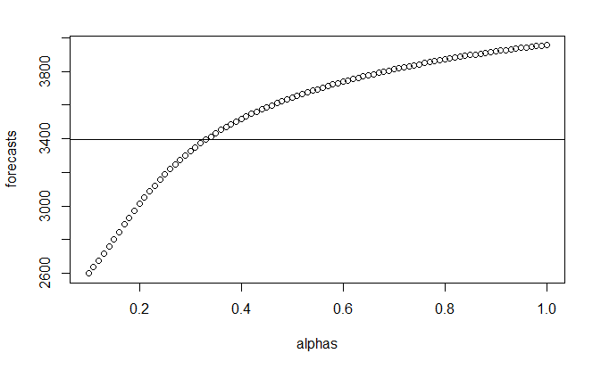

```r
locator(1)
```

The plot from these commands is shown in Figure 1. The last line in the commands plots a horizontal line at the value of l114. You can see that the closest forecast is around the value of 0.33. In fact, you can find out by typing locator(1) which allows you to click on the plot with the mouse, after clicking R returns the coordinates on the plot where you clicked. Therefore, our best choice of alpha is 0.33. You can now forecast L114 by typing

```r
lynx[104]+es(lynx10.2,alpha=0.33)
```

```
[1] 3393.116
```

and you should get ^l(113, 1) ??? 3393, which is better than the previous estimate.

You should also try the following R commands to forecast by using the AR model which we fitted in Lab Three to the log of the lynx data. This method is essentially Box-Jenkins forecasting.

```r
llynx=log(lynx)
llynx2=llynx[1:113]
fit=arima(llynx2,order=c(11,0,0))
predict(fit,n.ahead=1)
```

```
$`pred`
Time Series:
Start = 114
End = 114
Frequency = 1
[1] 8.113238

$se
Time Series:
Start = 114
End = 114
Frequency = 1
[1] 0.4395207
```

Exercise. Recife Dataset (a) Create a new data vector from the recife data by copying all the observations apart from the last 12 observations by using the command recife2=recife[1:108] We are pretending the last 12 observations are unknown. We’ll fit a model to recife2 and find forecasts for up to 12-steps ahead.

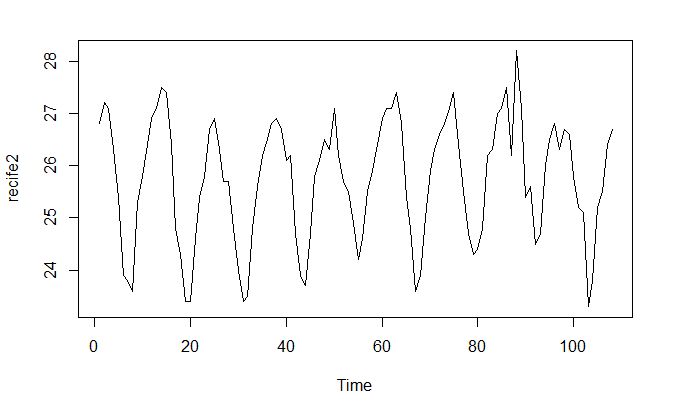

```r
recife2=recife[1:108] #define shorter recife vector
ts.plot(recife2)
```

[figure not shown]

I now have reason to believe the ARMA(1,3) model is suitable.

```r
fit <- arima(recife2, order = c(1,0,3), seasonal = list(order = c(0, 0, 0), period = 12)) #fit ARMA(1,3), seasonal model to the series
fit
```

```
Call:
arima(x = recife2, order = c(1, 0, 3), seasonal = list(order = c(0, 0, 0), period = 12))

Coefficients:
         ar1     ma1     ma2     ma3  intercept
      0.4383  0.5403  0.5207  0.4292    25.7579
s.e.  0.1243  0.1197  0.0941  0.0943     0.2626

sigma^2 estimated as 0.3923:  log likelihood = -103.62,  aic = 219.24
```

So I have the model Xt = 0.4383Xt-1 +Zt +0.5403Zt-1 +0.5207Zt-2 +0.4292Zt-3 +25.7579

```r
predict(fit, n.ahead = 12)
```

```
$`pred`
Time Series:
Start = 109
End = 120
Frequency = 1
 [1] 26.34077 26.14012 25.98525 25.85754 25.80156 25.77703 25.76628 25.76156
 [9] 25.75950 25.75859 25.75820 25.75802

$se
Time Series:
Start = 109
End = 120
Frequency = 1
 [1] 0.6263285 0.8763214 1.0591025 1.1840805 1.2066072 1.2108865 1.2117068
 [8] 1.2118644 1.2118946 1.2119004 1.2119015 1.2119018
```